# F Test Power Simulation - Variance

# Exploration

## Sample Size v.s. Power (for given population variances, $\sigma^{2}_1$, $\sigma^{2}_0$, and population means, $\mu_{1} = \mu_{0} = \mu$)

Test Data:

```r
var1popls <- rep(1.5, 10)
var0popls <- rep(1, 10)
mu1 <- 0
mu0 <- 0

alphas <- rep(0.05, 10)


ns <- seq(5, 500, length.out = 10)


var1s <- c()
var0s <- c()



for(i in 1:length(var1popls)){

  trt <- rnorm(ns[i], mean = mu1, sd = sqrt(var1popls[i]))

  var1s[i] <- (sd(trt))^2

  ctrl <- rnorm(ns[i], mean = mu0, sd = sqrt(var0popls[i]))

  var0s[i] <- (sd(ctrl))^2

}




result_table_var <- simulate_power_var(var1popls, var0popls, var1s, var0s, ns, ns, alphas)

result_table_var
```

```
## # A tibble: 10 x 3
##      phi     n  power
##    <dbl> <dbl>  <dbl>
##  1   1.5     5 0.0619
##  2   1.5    60 0.338
##  3   1.5   115 0.577
##  4   1.5   170 0.748
##  5   1.5   225 0.857
##  6   1.5   280 0.922
##  7   1.5   335 0.959
##  8   1.5   390 0.979
##  9   1.5   445 0.989
## 10   1.5   500 0.995
```

[figure not shown]

```r
ggplot(data = result_table_var, aes(x = n1, y = power)) +
  geom_point() +
  scale_x_continuous(limits = c(5, 500)) +
  scale_y_continuous(limits = c(0, 1)) +
  geom_hline(yintercept = 0.8, linetype = "dashed", color = "red")
```

```r
var1popls <- seq(10, 1, by = - 0.01)
var0popls <- rep(10, length(var1popls))
mu1 <- 0
mu0 <- 0


n1s <- rep(30, length(var1popls))
n0s <- rep(30, length(var1popls))


var1s <- c()
var0s <- c()

for(i in 1:length(var1popls)){

  trt <- rnorm(n1s[i], mean = mu1, sd = sqrt(var1popls[i]))

  var1s[i] <- (sd(trt))^2

  ctrl <- rnorm(n0s[i], mean = mu0, sd = sqrt(var0popls[i]))

  var0s[i] <- (sd(ctrl))^2

}

alphas<- rep(0.05, length(var1popls))


result_table_phi <- simulate_power_var(var1popls, var0popls, var1s, var0s, n1s, n0s, alphas)
```

Plot phi v.s. power

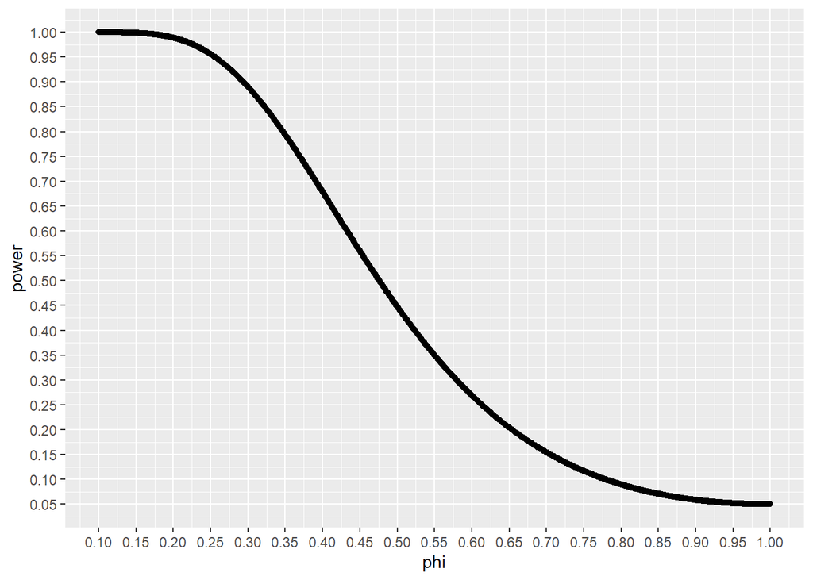

```r
ggplot(result_table_phi, aes(x = phi, y = power)) +
  geom_point() +
  scale_x_continuous(breaks = seq(0, 1, by = 0.05)) +
  scale_y_continuous(breaks = seq(0, 1, by = 0.05))
```

```r
  theme(axis.text.x = element_text(angle = 295, vjust = 0.5, hjust=1))
```

[output not shown]

1. As $\phi\rightarrow 1$, power declines.
2. As $\phi\rightarrow 1$, the rate of decline of the power increases and then decreases.
3. As $\phi\rightarrow 1$, the power decreases faster for $\phi\in [0.30, 0.60]$ than for $\phi\in (0, 0.30)\cup(0.6, 1)$.

## Different Sample Sizes with the Same Phi

```r
n1s <- seq(10, 100, by = 1)
n0s <- rep(100, length(n1s))

var1popls <- rep(5, length(n1s))
var0popls <- rep(10, length(n1s))
mu1 <- 0
mu0 <- 0





var1s <- c()
var0s <- c()

for(i in 1:length(var1popls)){

  trt <- rnorm(n1s[i], mean = mu1, sd = sqrt(var1popls[i]))

  var1s[i] <- (sd(trt))^2

  ctrl <- rnorm(n0s[i], mean = mu0, sd = sqrt(var0popls[i]))

  var0s[i] <- (sd(ctrl))^2

}

alphas <- rep(0.05, length(n1s))


result_table_size <- simulate_power_var(var1popls, var0popls, var1s, var0s, n1s, n0s, alphas)
```

Plot sample size v.s. power

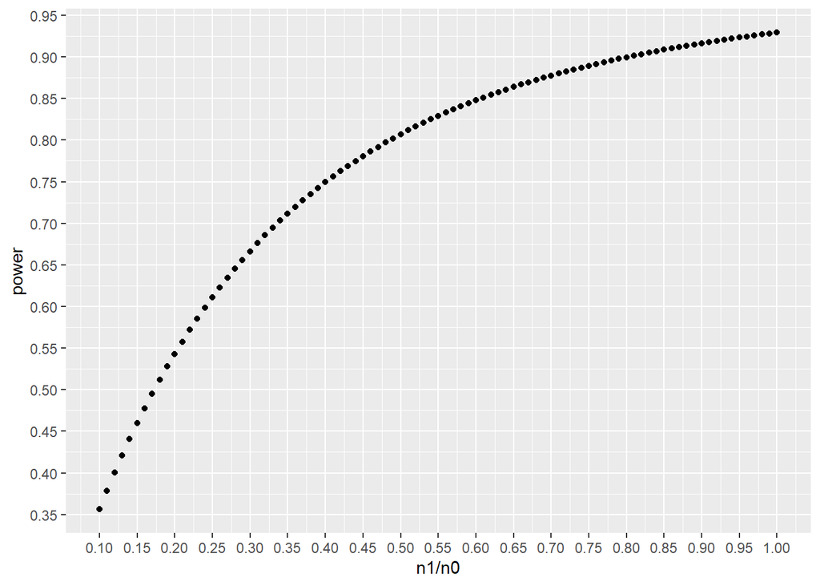

```r
ggplot(result_table_size, aes(x = n1/n0, y = power)) +
  geom_point() +
  scale_x_continuous(breaks = seq(0, 1, by = 0.05)) +
  scale_y_continuous(breaks = seq(0, 1, by = 0.05))
```

```r
  theme(axis.text.x = element_text(angle = 295, vjust = 0.5, hjust=1))
```

[output not shown]

1. As $\frac{n_1}{n_0}\rightarrow 1$, power increases.
2. As $\frac{n_1}{n_0}\rightarrow 1$, the rate of increase of power decreases.

## Sample Size, Phi and Power

### $\phi = 0.95$

```r
n1s <- seq(10, 200, by = 1)
n0s <- n1s

var1popls <- rep(9.5, length(n1s))
var0popls <- rep(10, length(n1s))
mu1 <- 0
mu0 <- 0





var1s <- c()
var0s <- c()

for(i in 1:length(var1popls)){

  trt <- rnorm(n1s[i], mean = mu1, sd = sqrt(var1popls[i]))

  var1s[i] <- (sd(trt))^2

  ctrl <- rnorm(n0s[i], mean = mu0, sd = sqrt(var0popls[i]))

  var0s[i] <- (sd(ctrl))^2

}

alphas <- rep(0.05, length(n1s))


result_table_phi95 <- simulate_power_var(var1popls, var0popls, var1s, var0s, n1s, n0s, alphas)
```

Plot sample size v.s. power for $\phi = 0.95$

[figure not shown]

```r
phi95 <- ggplot(result_table_phi95, aes(x = n1, y = power)) +
  geom_point() +
  scale_x_continuous(breaks = seq(5, 210, by = 10)) +
  scale_y_continuous(breaks = seq(0, 1, by = 0.001)) +
  theme(axis.text.x = element_text(angle = 90, vjust = 0.5, hjust=1))

phi95
```

### $\phi = 0.9$

```r
n1s <- seq(10, 200, by = 1)
n0s <- n1s

var1popls <- rep(9, length(n1s))
var0popls <- rep(10, length(n1s))
mu1 <- 0
mu0 <- 0





var1s <- c()
var0s <- c()

for(i in 1:length(var1popls)){

  trt <- rnorm(n1s[i], mean = mu1, sd = sqrt(var1popls[i]))

  var1s[i] <- (sd(trt))^2

  ctrl <- rnorm(n0s[i], mean = mu0, sd = sqrt(var0popls[i]))

  var0s[i] <- (sd(ctrl))^2

}

alphas <- rep(0.05, length(n1s))


result_table_phi90 <- simulate_power_var(var1popls, var0popls, var1s, var0s, n1s, n0s, alphas)
```

Plot sample size v.s. power for $\phi = 0.9$

[figure not shown]

```r
phi90 <- ggplot(result_table_phi90, aes(x = n1, y = power)) +
  geom_point() +
  scale_x_continuous(breaks = seq(5,230, by = 10)) +
  scale_y_continuous(breaks = seq(0, 1, by = 0.01)) +
  theme(axis.text.x = element_text(angle = 90, vjust = 0.5, hjust=1))

phi90
```

### $\phi = 0.7$

```r
n1s <- seq(10, 200, by = 1)
n0s <- n1s

var1popls <- rep(7, length(n1s))
var0popls <- rep(10, length(n1s))
mu1 <- 0
mu0 <- 0





var1s <- c()
var0s <- c()

for(i in 1:length(var1popls)){

  trt <- rnorm(n1s[i], mean = mu1, sd = sqrt(var1popls[i]))

  var1s[i] <- (sd(trt))^2

  ctrl <- rnorm(n0s[i], mean = mu0, sd = sqrt(var0popls[i]))

  var0s[i] <- (sd(ctrl))^2

}

alphas <- rep(0.05, length(n1s))


result_table_phi70 <- simulate_power_var(var1popls, var0popls, var1s, var0s, n1s, n0s, alphas)
```

Plot sample size v.s. power for $\phi = 0.7$

[figure not shown]

```r
phi70 <- ggplot(result_table_phi70, aes(x = n1, y = power)) +
  geom_point() +
  scale_x_continuous(breaks = seq(5, 210, by = 10)) +
  scale_y_continuous(breaks = seq(0, 1, by = 0.05)) +
  theme(axis.text.x = element_text(angle = 90, vjust = 0.5, hjust=1))

phi70
```

### $\phi = 0.5$

```r
n1s <- seq(10, 200, by = 1)
n0s <- n1s

var1popls <- rep(5, length(n1s))
var0popls <- rep(10, length(n1s))
mu1 <- 0
mu0 <- 0





var1s <- c()
var0s <- c()

for(i in 1:length(var1popls)){

  trt <- rnorm(n1s[i], mean = mu1, sd = sqrt(var1popls[i]))

  var1s[i] <- (sd(trt))^2

  ctrl <- rnorm(n0s[i], mean = mu0, sd = sqrt(var0popls[i]))

  var0s[i] <- (sd(ctrl))^2

}

alphas <- rep(0.05, length(n1s))


result_table_phi50 <- simulate_power_var(var1popls, var0popls, var1s, var0s, n1s, n0s, alphas)
```

Plot sample size v.s. power for $\phi = 0.5$

[figure not shown]

```r
phi50 <- ggplot(result_table_phi50, aes(x = n1, y = power)) +
  geom_point() +
  scale_x_continuous(breaks = seq(5, 210, by = 10)) +
  scale_y_continuous(breaks = seq(0, 1, by = 0.05)) +
  theme(axis.text.x = element_text(angle = 90, vjust = 0.5, hjust=1))

phi50
```

Compare

[figure not shown]

```r
ggarrange(phi95, phi90, phi70, phi50,
          labels = c("phi = 0.95", "phi = 0.9", "phi = 0.7", "phi = 0.5"),
          label.x = 0.5,
          label.y = 0.5,
          font.label = list(size = 12),
          ncol = 2, nrow = 2)
```